Reproducible Research Peer Assignment 2

1. Synopsis

We analyzed the data of natural events from the U.S. National Oceanic and Atmospheric Administration’s (NOAA) storm database. We first read the data and clean up some event types by looking into the cookbook. Then we aggregate the fatality, body injury, property damag, and crop damage by using the aggregate function according to different event types. With data processing and analyzing, we summarized the most harmful events to human health and the events have strongest damage to property and crop by table and figures. The results are tornado, thunderstrom wind, flood, excessive heat are the most harmful events to human health while while flood, hurricane, tornado, storm surge and hail have the most economic consequences.

2. Data processing

In this file, we are going to analyze how different types of natural events have impact on human health and property damage. Firts, we are going to do the data processing.

```r
data <- read.csv(bzfile("repdata_data_StormData.csv.bz2"), header = TRUE)

data$EVTYPE = toupper(data$EVTYPE)
dim(data)
```

```
## [1] 902297     37
```

```r
head(data)
```

```
##   STATE__           BGN_DATE BGN_TIME TIME_ZONE COUNTY COUNTYNAME STATE
## 1       1  4/18/1950 0:00:00     0130       CST     97     MOBILE    AL
## 2       1  4/18/1950 0:00:00     0145       CST      3    BALDWIN    AL
## 3       1  2/20/1951 0:00:00     1600       CST     57    FAYETTE    AL
## 4       1   6/8/1951 0:00:00     0900       CST     89    MADISON    AL
## 5       1 11/15/1951 0:00:00     1500       CST     43    CULLMAN    AL
## 6       1 11/15/1951 0:00:00     2000       CST     77 LAUDERDALE    AL
##    EVTYPE BGN_RANGE BGN_AZI BGN_LOCATI END_DATE END_TIME COUNTY_END
## 1 TORNADO         0                                               0
## 2 TORNADO         0                                               0
## 3 TORNADO         0                                               0
## 4 TORNADO         0                                               0
## 5 TORNADO         0                                               0
## 6 TORNADO         0                                               0
##   COUNTYENDN END_RANGE END_AZI END_LOCATI LENGTH WIDTH F MAG FATALITIES
```

[output cut: 20 more lines]

By doing this, weload the data and we keep all of the events name to upper cases which could help to combine in the following.

From the page 6 of the cookbook, we found there are several types of events which are represented in more than one names, Therefore, we change the name of these events as following.

```r
data[data$EVTYPE == "TSTM WIND", ]$EVTYPE = "THUNDERSTORM WIND"
data[data$EVTYPE == "THUNDERSTORM WINDS", ]$EVTYPE = "THUNDERSTORM WIND"
data[data$EVTYPE == "RIVER FLOOD", ]$EVTYPE = "FLOOD"
data[data$EVTYPE == "HURRICANE/TYPHOON", ]$EVTYPE = "HURRICANE-TYPHOON"
data[data$EVTYPE == "HURRICANE", ]$EVTYPE = "HURRICANE-TYPHOON"
```

3. Results

3.1 The most harmful events to human healths

First, let’s revisit the information of this data set in the second part.

We find that this sets data counts four types of damage: fatality (FATALITIES) , injury (INJURIES), property damage (PROPDMG) and crop damage (CROPDMG) , while the latter two should be calculated with magnitude, PROPDMGEXP and CROPDMGEXP. Since only the first two items related to human health directly, we summarized these two types of data here.

```r
fatal <- aggregate(FATALITIES ~ EVTYPE, data = data, sum)
fatal1 <- fatal[fatal$FATALITIES > 0, ]
fatalorder <- fatal1[order(fatal1$FATALITIES, decreasing = TRUE), ]
head(fatalorder)
```

```
##                EVTYPE FATALITIES
## 755           TORNADO       5633
## 116    EXCESSIVE HEAT       1903
## 138       FLASH FLOOD        978
## 243              HEAT        937
## 417         LIGHTNING        816
## 683 THUNDERSTORM WIND        701
```

The code above aggregates the fatality data by event type and rank them in the decreasing order. We can find that tornado and excessive heat are two of the most events which cause fatality in the past years since 1950. Next, we will summary the data of injury.

```r
injury <- aggregate(INJURIES ~ EVTYPE, data = data, sum)
injury1 <- injury[injury$INJURIES > 0, ]
injuryorder <- injury1[order(injury1$INJURIES, decreasing = TRUE), ]
head(injuryorder)
```

```
##                EVTYPE INJURIES
## 755           TORNADO    91346
## 683 THUNDERSTORM WIND     9353
## 154             FLOOD     6791
## 116    EXCESSIVE HEAT     6525
## 417         LIGHTNING     5230
## 243              HEAT     2100
```

Then we can draw a panel of two figures which contains both fatality and injury data.

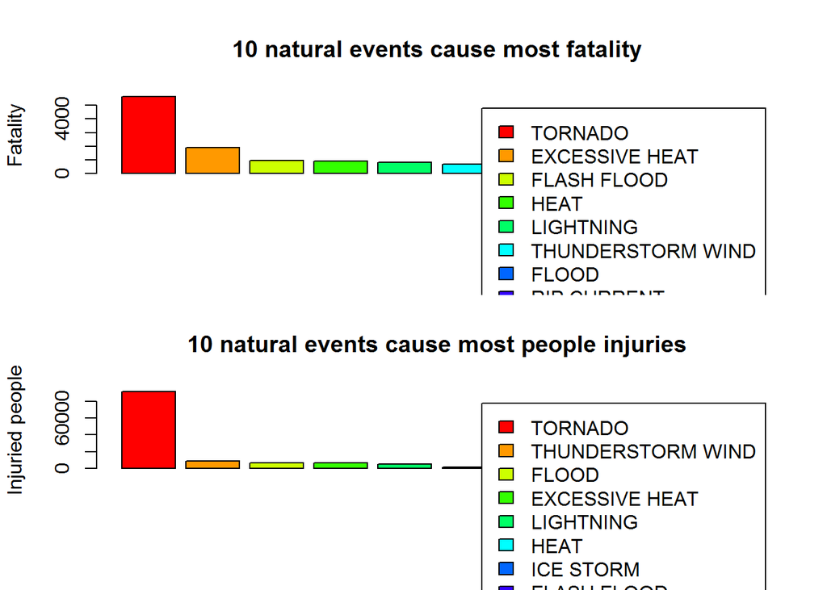

```r
par(mfrow = c(2, 1))
barplot(fatalorder[1:10, 2], col = rainbow(10), legend.text = fatalorder[1:10,
    1], ylab = "Fatality", main = "10 natural events cause most fatality")
barplot(injuryorder[1:10, 2], col = rainbow(10), legend.text = injuryorder[1:10,
    1], ylab = "Injuried people", main = "10 natural events cause most people injuries")
```

plot of chunk unnamed-chunk-5

We can also find what events cause both major fatality and body injury.

```r
intersect(fatalorder[1:10, 1], injuryorder[1:10, 1])
```

```
## [1] "TORNADO"           "EXCESSIVE HEAT"    "FLASH FLOOD"
## [4] "HEAT"              "LIGHTNING"         "THUNDERSTORM WIND"
## [7] "FLOOD"
```

There are 7 types of events which are listed in top 10 of fatality and body injury.

3.2 The most harmful events to properties

In this chapter, we try to summarize the property damage and crop damage caused by these natural events.

```r
unique(data$PROPDMGEXP)
```

```
##  [1] K M   B m + 0 5 6 ? 4 2 3 h 7 H - 1 8
## Levels:  - ? + 0 1 2 3 4 5 6 7 8 B h H K m M
```

```r
unique(data$CROPDMGEXP)
```

```
## [1]   M K m B ? 0 k 2
## Levels:  ? 0 2 B k K m M
```

From the page 12 of the cookbook, the letter “K” stands for thousands, while “M” for millions and “B” for billions. however, we find both upper and lower case from these letters. The first thing we need to do is to transform the exponential terms back into actual values.

```r
data[data$PROPDMGEXP == "K", ]$PROPDMG <- data[data$PROPDMGEXP == "K", ]$PROPDMG *
    1000
data[data$PROPDMGEXP == "M", ]$PROPDMG <- data[data$PROPDMGEXP == "M", ]$PROPDMG *
    1e+06
data[data$PROPDMGEXP == "m", ]$PROPDMG <- data[data$PROPDMGEXP == "m", ]$PROPDMG *
    1e+06
data[data$PROPDMGEXP == "B", ]$PROPDMG <- data[data$PROPDMGEXP == "B", ]$PROPDMG *
    1e+09
data[data$CROPDMGEXP == "K", ]$CROPDMG <- data[data$CROPDMGEXP == "K", ]$CROPDMG *
    1000
data[data$CROPDMGEXP == "k", ]$CROPDMG <- data[data$CROPDMGEXP == "k", ]$CROPDMG *
    1000
data[data$CROPDMGEXP == "M", ]$CROPDMG <- data[data$CROPDMGEXP == "M", ]$CROPDMG *
    1e+06
data[data$CROPDMGEXP == "m", ]$CROPDMG <- data[data$CROPDMGEXP == "m", ]$CROPDMG *
    1e+06
data[data$CROPDMGEXP == "B", ]$CROPDMG <- data[data$CROPDMGEXP == "B", ]$CROPDMG *
    1e+09
```

Therefore, we can aggregate the propery damage and crop damage by event types and rank them in decreasing order.

```r
damage <- aggregate(PROPDMG ~ EVTYPE, data = data, sum)
damage1 <- damage[damage$PROPDMG > 0, ]
damageorder <- damage1[order(damage1$PROPDMG, decreasing = TRUE), ]
head(damageorder)
```

```
##                EVTYPE      PROPDMG
## 154             FLOOD 149776655307
## 364 HURRICANE-TYPHOON  81174159010
## 755           TORNADO  56937160779
## 597       STORM SURGE  43323536000
## 138       FLASH FLOOD  16140812067
## 212              HAIL  15732267048
```

We find the flood is the most harmful event as regarding to property damage, while the second most harmful event is hurricane(typhoon).

```r
cropdmg <- aggregate(CROPDMG ~ EVTYPE, data = data, sum)
cropdmg1 <- cropdmg[cropdmg$CROPDMG > 0, ]
cropdmgorder <- cropdmg1[order(cropdmg1$CROPDMG, decreasing = TRUE), ]
head(cropdmgorder)
```

```
##                EVTYPE     CROPDMG
## 84            DROUGHT 13972566000
## 154             FLOOD 10691427450
## 364 HURRICANE-TYPHOON  5349782800
## 386         ICE STORM  5022113500
## 212              HAIL  3025954473
## 138       FLASH FLOOD  1421317100
```

This time we found that drought is the most harmful event causing crop damage while the flood and hurricane(typhoon) are the second and third harmful events.

The next thing is to use a panel of two figures to show the most 10 harmful events in two categories.

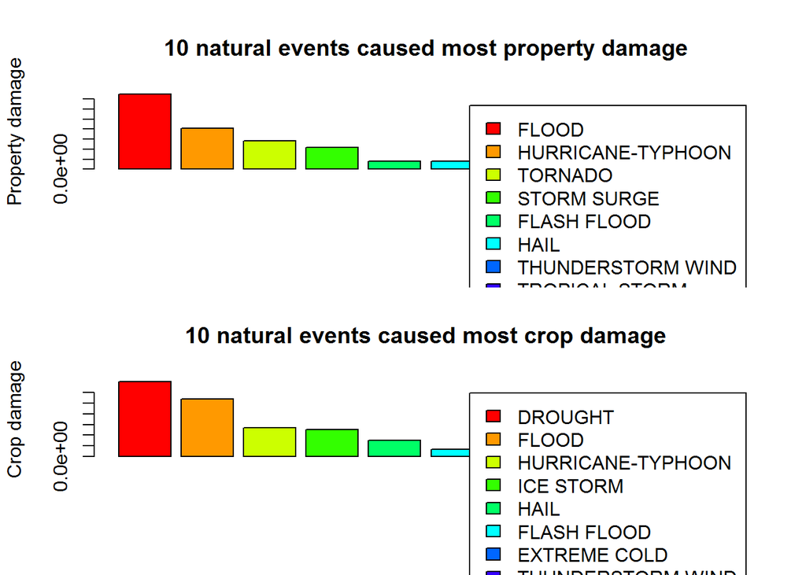

```r
par(mfrow = c(2, 1))
barplot(damageorder[1:10, 2], col = rainbow(10), legend.text = damageorder[1:10,
    1], ylab = "Property damage", main = "10 natural events caused most property damage")
barplot(cropdmgorder[1:10, 2], col = rainbow(10), legend.text = cropdmgorder[1:10,
    1], ylab = "Crop damage", main = "10 natural events caused most crop damage")
```

plot of chunk unnamed-chunk-11

We can see the sequence of two types of damages are different, so we can add these two types of damage together to see to sum.

```r
totaldmg <- merge(damageorder, cropdmgorder, by = "EVTYPE")
totaldmg$total = totaldmg$PROPDMG + totaldmg$CROPDMG
totaldmgorder <- totaldmg[order(totaldmg$total, decreasing = TRUE), ]
totaldmgorder[1:5, ]
```

```
##               EVTYPE      PROPDMG     CROPDMG        total
## 19             FLOOD 149776655307 10691427450 160468082757
## 48 HURRICANE-TYPHOON  81174159010  5349782800  86523941810
## 82           TORNADO  56937160779   414953270  57352114049
## 66       STORM SURGE  43323536000        5000  43323541000
## 31              HAIL  15732267048  3025954473  18758221521
```

We can see the 5 events cause most economic consequences are flood, hurricane, tornado, storm surge and hail.